Liverpool City Region active-travel monitoring

# Vivacity before/after averages and wider sensor context

This updated report combines the five scheme temporal profiles, fixed-year comparisons, the wider Liverpool City Region benchmark, IMD-based comparisons, separate pedestrian and cyclist pre-intervention trajectory matching, and weather-control sensitivity analysis. Other sensors without the required comparison observations are excluded from the relevant analyses.

Section 1

## Requested before-and-after year comparisons

Annual totals divided by observed countline-days. Pedestrian and cyclist outcomes are shown separately; active travel is their sum.

**Availability:** no 2023-installed scheme has a usable 2021 baseline after applying the confirmed first-reliable dates and daily quality rule, so the 2021–2024 panels remain descriptive on the 2024 side only. The 2022–2025 comparison is available for schemes 12d and 12f. For scheme 13, 2022 has no usable baseline, 2023–2025 is available, and 2026 covers data only to 26 May.

**WP3a Prescot to Cronton | Cronton Road / Sandy Lane Installed 2023-03-01**

#### Pedestrian

No comparable baseline

Before2021

No data

After2024

81.9

No usable 2021 baseline remains after the confirmed first-reliable-date and availability rules.

#### Cyclist

No comparable baseline

Before2021

No data

After2024

23.3

No usable 2021 baseline remains after the confirmed first-reliable-date and availability rules.

#### Active travel

No comparable baseline

Before2021

No data

After2024

105.2

No usable 2021 baseline remains after the confirmed first-reliable-date and availability rules.

**WP3a Prescot to Cronton | Cronton Road / Sandy Lane Installed 2023-03-01**

#### Pedestrian

No comparable baseline

Before2022

No data

After2025

74.4

No usable 2022 baseline remains after the confirmed first-reliable-date and availability rules.

#### Cyclist

No comparable baseline

Before2022

No data

After2025

23.1

No usable 2022 baseline remains after the confirmed first-reliable-date and availability rules.

#### Active travel

No comparable baseline

Before2022

No data

After2025

97.5

No usable 2022 baseline remains after the confirmed first-reliable-date and availability rules.

**WP1 Otterspool Promenade | Aigburth Road Installed 2023-03-01**

#### Pedestrian

No comparable baseline

Before2021

No data

After2024

138.6

No usable 2021 baseline remains after the confirmed first-reliable-date and availability rules.

#### Cyclist

No comparable baseline

Before2021

No data

After2024

37.6

No usable 2021 baseline remains after the confirmed first-reliable-date and availability rules.

#### Active travel

No comparable baseline

Before2021

No data

After2024

176.2

No usable 2021 baseline remains after the confirmed first-reliable-date and availability rules.

**WP1 Otterspool Promenade | Aigburth Road Installed 2023-03-01**

#### Pedestrian

+21.7%

Before2022

107.7

After2025

131.1

The 2025 average is higher by 23.4 per observed countline-day.

#### Cyclist

+14.5%

Before2022

33.4

After2025

38.2

The 2025 average is higher by 4.8 per observed countline-day.

#### Active travel

+20.0%

Before2022

141.1

After2025

169.3

The 2025 average is higher by 28.2 per observed countline-day.

**WP5 Sankey Canal to St Helens | Park Road / Path off Park Road Installed 2023-03-01**

#### Pedestrian

No comparable baseline

Before2021

No data

After2024

159.6

No usable 2021 baseline remains after the confirmed first-reliable-date and availability rules.

#### Cyclist

No comparable baseline

Before2021

No data

After2024

32.5

No usable 2021 baseline remains after the confirmed first-reliable-date and availability rules.

#### Active travel

No comparable baseline

Before2021

No data

After2024

192.0

No usable 2021 baseline remains after the confirmed first-reliable-date and availability rules.

**WP5 Sankey Canal to St Helens | Park Road / Path off Park Road Installed 2023-03-01**

#### Pedestrian

No comparable baseline

Before2022

No data

After2025

150.2

No usable 2022 baseline remains after the confirmed first-reliable-date and availability rules.

#### Cyclist

No comparable baseline

Before2022

No data

After2025

29.5

No usable 2022 baseline remains after the confirmed first-reliable-date and availability rules.

#### Active travel

No comparable baseline

Before2022

No data

After2025

179.7

No usable 2022 baseline remains after the confirmed first-reliable-date and availability rules.

**WP6 Leasowe to Wallasey Bridge Road | Leasowe Road / Wallasey corridor Installed 2023-06-01**

#### Pedestrian

No comparable baseline

Before2021

No data

After2024

72.2

No usable 2021 baseline remains after the confirmed first-reliable-date and availability rules.

#### Cyclist

No comparable baseline

Before2021

No data

After2024

33.6

No usable 2021 baseline remains after the confirmed first-reliable-date and availability rules.

#### Active travel

No comparable baseline

Before2021

No data

After2024

105.8

No usable 2021 baseline remains after the confirmed first-reliable-date and availability rules.

**WP6 Leasowe to Wallasey Bridge Road | Leasowe Road / Wallasey corridor Installed 2023-06-01**

#### Pedestrian

+47.2%

Before2022

45.0

After2025

66.3

The 2025 average is higher by 21.3 per observed countline-day.

#### Cyclist

+61.0%

Before2022

20.5

After2025

33.0

The 2025 average is higher by 12.5 per observed countline-day.

#### Active travel

+51.5%

Before2022

65.6

After2025

99.3

The 2025 average is higher by 33.8 per observed countline-day.

**LCR Cycle Network phase 2 Runcorn to Daresbury | Astmoor Busway / Warrington Road Installed 2024-03-01**

#### Pedestrian

No comparable baseline

Before2022

No data

After2026

22.3

No usable 2022 baseline remains after the confirmed first-reliable-date and availability rules.

#### Cyclist

No comparable baseline

Before2022

No data

After2026

38.2

No usable 2022 baseline remains after the confirmed first-reliable-date and availability rules.

#### Active travel

No comparable baseline

Before2022

No data

After2026

60.5

No usable 2022 baseline remains after the confirmed first-reliable-date and availability rules.

**LCR Cycle Network phase 2 Runcorn to Daresbury | Astmoor Busway / Warrington Road Installed 2024-03-01**

#### Pedestrian

-35.8%

Before2023

64.7

After2025

41.5

The 2025 average is lower by 23.2 per observed countline-day.

#### Cyclist

+8.3%

Before2023

43.7

After2025

47.3

The 2025 average is higher by 3.6 per observed countline-day.

#### Active travel

-18.1%

Before2023

108.4

After2025

88.8

The 2025 average is lower by 19.6 per observed countline-day.

Section 2

## Monthly temporal profiles for the five schemes

These are the HTML equivalents of the spreadsheet temporal visualisations, using the same official data and denominator.

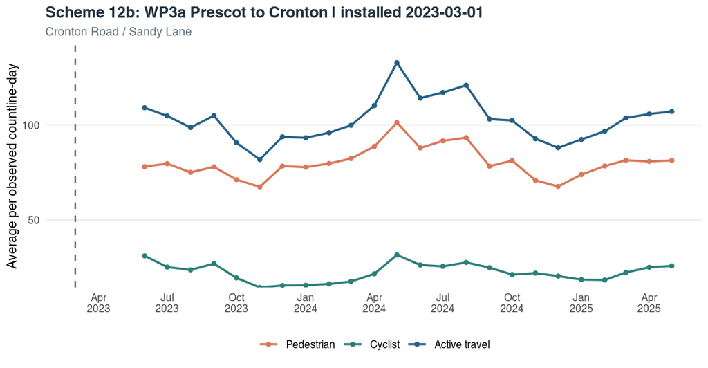

Dashed line: exact confirmed installation date. A line outside the observed series means reliable sensor data begin after installation.

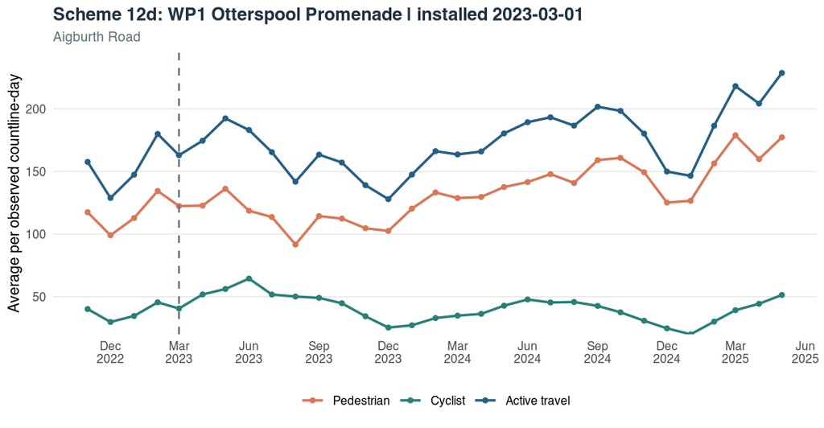

Dashed line: exact confirmed installation date. A line outside the observed series means reliable sensor data begin after installation.

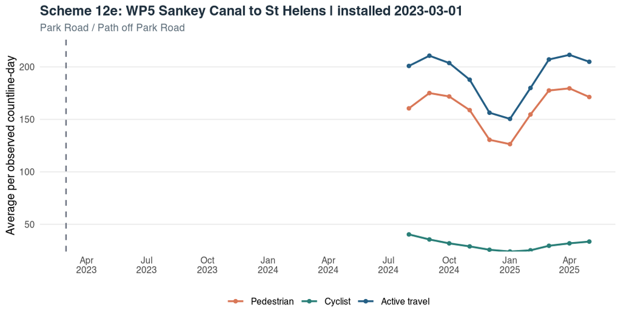

Dashed line: exact confirmed installation date. A line outside the observed series means reliable sensor data begin after installation.

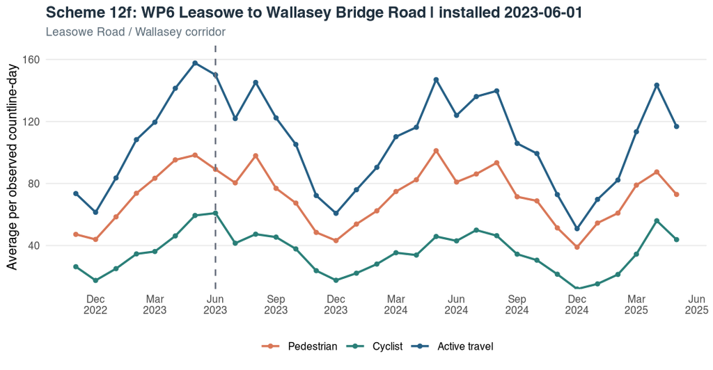

Dashed line: exact confirmed installation date. A line outside the observed series means reliable sensor data begin after installation.

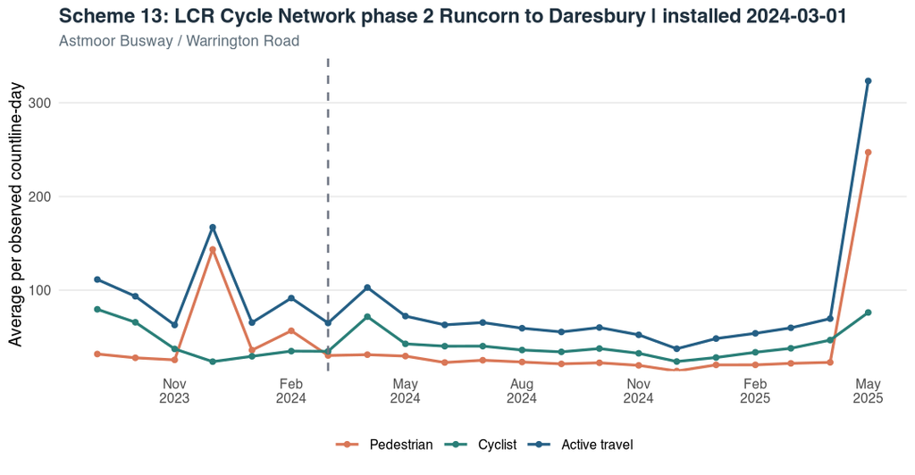

Dashed line: exact confirmed installation date. A line outside the observed series means reliable sensor data begin after installation.

Section 3

## Comparable sensors in the rest of the city region

“Rest of the city” means the remainder of the Liverpool City Region network, not Liverpool local authority alone. Only sensors with quality-passing observations in both 2022 and 2024 are retained.

Eligible other countlines**149**

Other countlines excluded**488**

Eligible matched sensor-days**36,724**

Exact matched calendar days**288**

The eligibility cohort contains 149 sensors with at least one quality-passing full day in 2022 and at least one in 2024. The other 488 sensors are removed from every LCR-wide table, chart, and comparison. No other LCR sensor has a usable 2021 observation, so a matching LCR-wide comparison beginning in 2021 cannot be produced.

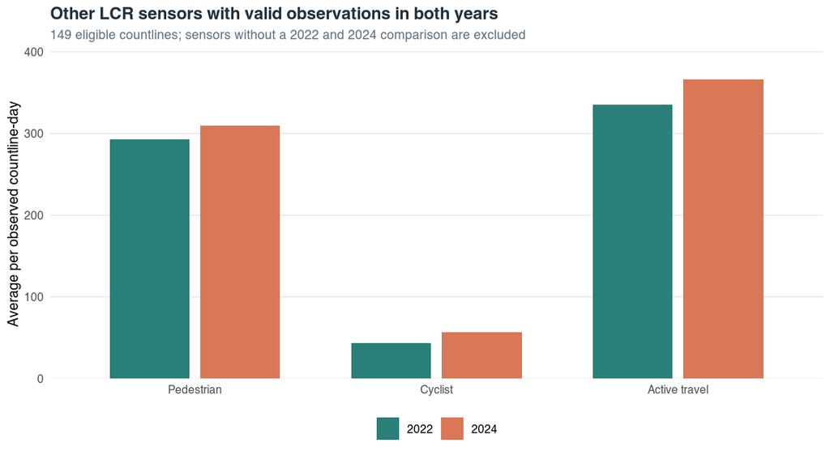

| Outcome | 2022 avg/day | 2024 avg/day | Difference | Change |
| --- | --- | --- | --- | --- |
| Pedestrian | 292.3 | 309.4 | 17.1 | +5.8% |
| Cyclist | 43.2 | 57.1 | 13.9 | +32.3% |
| Active travel | 335.5 | 366.5 | 31.0 | +9.2% |

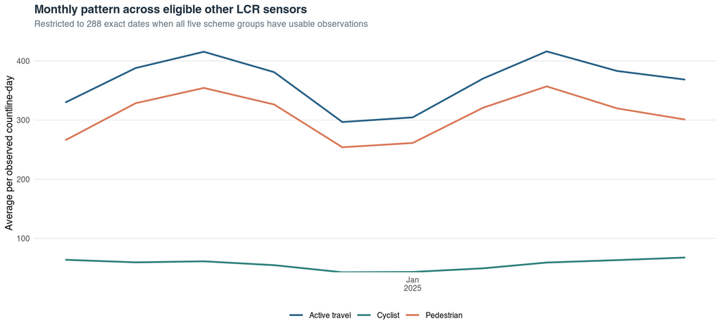

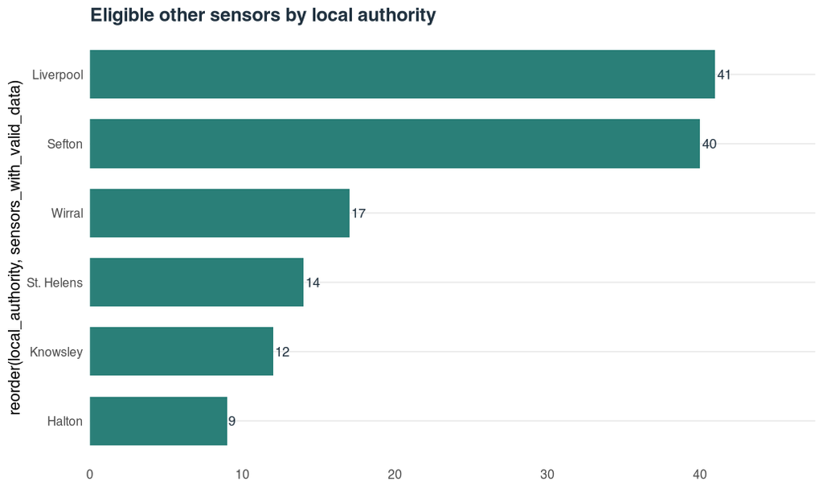

Counts refer only to the 2022–2024 eligible other-sensor cohort on the exact five-scheme matched dates.

| Local authority | Usable countlines | Sensor-days |
| --- | --- | --- |
| Liverpool | 41 | 11,310 |
| Sefton | 40 | 10,816 |
| Wirral | 17 | 4,848 |
| St. Helens | 14 | 3,905 |
| Knowsley | 12 | 3,387 |
| Halton | 9 | 2,458 |

| Route type | Usable countlines | Sensor-days |
| --- | --- | --- |
| Path/cycle facility | 71 | 20,039 |
| Road | 47 | 12,826 |
| Other / crossing | 15 | 3,859 |

Section 4

## Five scheme sensors compared with eligible other LCR sensors

The bar chart normalizes each group’s combined active-travel average to 100%, allowing pedestrian and cyclist composition to be compared without the larger other-sensor totals dominating the scale.

**Interpret carefully:** exact day matching removes differences caused by comparing different calendar dates, but this remains a contextual benchmark rather than a matched-location control or causal estimate. The five scheme locations were selected for active-travel investment and have a different mix of roads and paths from the wider sensor network. On these matched dates, 20 scheme countlines and 133 other countlines contribute; one of the 21 scheme countlines has no quality-passing observation on the matched dates.

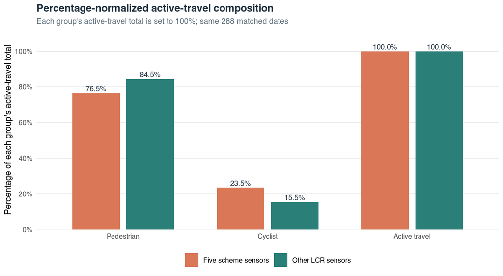

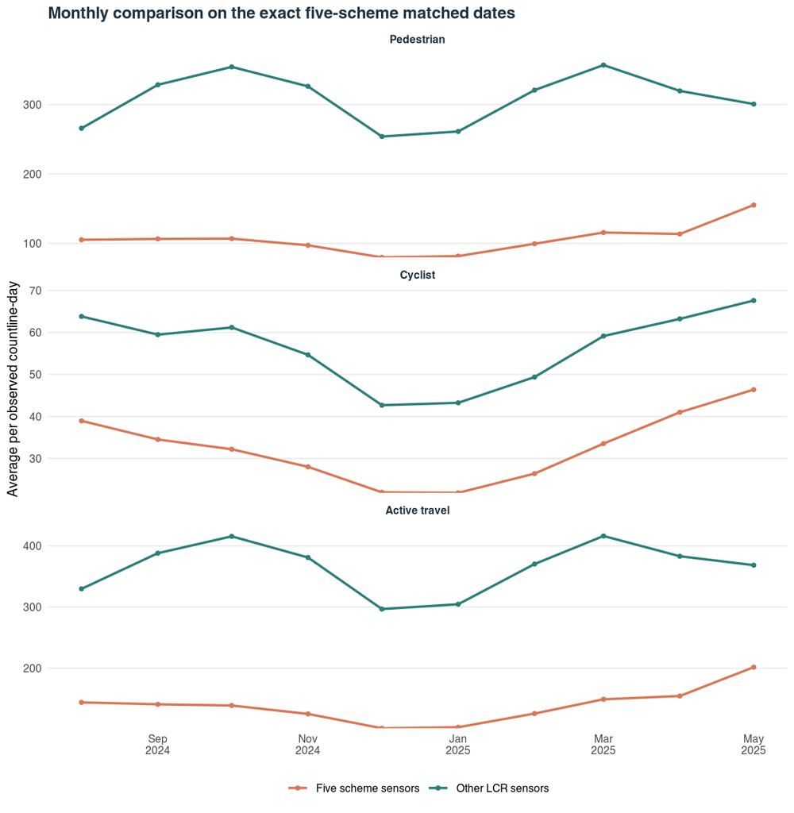

| Outcome | Scheme share of active travel | Other share of active travel | Scheme sensors pooled avg/day | Other sensors pooled avg/day | Difference | Ratio | Median scheme sensor | Median other sensor |
| --- | --- | --- | --- | --- | --- | --- | --- | --- |
| Pedestrian | 76.5% | 84.5% | 107.2 | 308.8 | -201.7 | 0.35x | 46.2 | 99.3 |
| Cyclist | 23.5% | 15.5% | 33.0 | 56.6 | -23.6 | 0.58x | 28.7 | 28.6 |
| Active travel | 100.0% | 100.0% | 140.1 | 365.5 | -225.3 | 0.38x | 78.5 | 151.9 |

**How to read the percentages:** active travel equals pedestrian plus cyclist, so active travel is 100% for both groups. The pedestrian and cyclist percentages show the composition within each group, not the relative number of movements between groups. Raw pooled averages remain in the table. The pooled average weights each observed sensor-day equally after restricting both groups to the same calendar dates.

Section 5

## Did the analysable schemes increase more than the LCR comparison trend?

This 2022–2024 baseline-adjusted model is limited to schemes 12d and 12f because they are the only schemes with usable 2022 pre-installation observations. It cannot estimate a five-scheme causal effect.

**Headline finding:** on paired 15 November–31 December dates, the 126 eligible LCR comparison sensors changed by an adjusted +2.5% in combined active travel, while the seven balanced scheme countlines changed by approximately -31.3%. The scheme trajectory was therefore 33.0% lower relative to the LCR comparison trend. The clustered 95% interval is -56.5% to +3.2% with p = 0.0694. An equal-weight sensor-level robustness test gives p = 0.133. Combined active travel is therefore directionally lower, but statistically inconclusive.

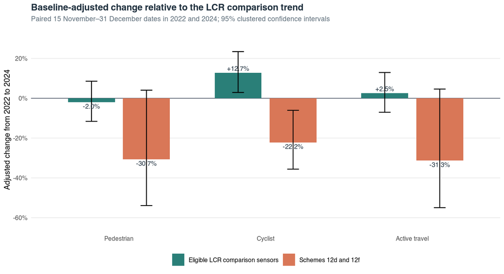

| Outcome | LCR adjusted change | Scheme adjusted change | Scheme relative to LCR | Clustered 95% CI | Clustered p | Sensor-level p | Interpretation |
| --- | --- | --- | --- | --- | --- | --- | --- |
| Pedestrian | -2.0% | -30.7% | -29.3% | -53.5% to +7.6% | 0.105 | 0.162 | Lower point estimate; not conclusive in both checks |
| Cyclist | +12.7% | -22.2% | -31.0% | -44.0% to -14.9% | <0.001 | 0.0115 | Lower than LCR trend in both inference checks |
| Active travel | +2.5% | -31.3% | -33.0% | -56.5% to +3.2% | 0.0694 | 0.133 | Lower point estimate; not conclusive in both checks |

The cyclist result is the most consistent evidence of a weaker scheme trajectory: the eligible LCR comparison sensors increased by +12.7%, whereas the balanced scheme countlines changed by -22.2%; the relative difference is -31.0%. Both the clustered model (p = <0.001) and the equal-weight sensor-level check (p = 0.0115) retain this direction. Nevertheless, these are exploratory associations. Only seven treated countlines are available and scheme placement was non-random. Pre-intervention trajectory matching is assessed separately in Section 7 and weather in Section 8.

Section 6

## Cross-comparison with IMD-matched street sensors

Each of the six scheme LSOA contexts is paired with the route-compatible non-intervention street whose available sensor area has the nearest selected IMD score.

**Matching structure:** the five schemes occupy six LSOA contexts because scheme 12e spans St. Helens 008C and St. Helens 014D. The descriptive comparison uses 218 exact dates from 2024-08-01 to 2025-04-24, when every scheme context and its paired street have usable observations. 20 scheme countlines and 20 matched-street countlines contribute.

| Scheme context | Scheme-area IMD | Paired street and LSOA | Paired-area IMD | Score difference | Post-period volume ratio | Control countline IDs |
| --- | --- | --- | --- | --- | --- | --- |
| 12b \| Knowsley 017B | 14.604 (decile 6) | Liver St near Park Ln Liverpool 061C | 15.028 (decile 6) | 0.424 | 0.06x Large volume difference | 16364, 16365, 16388, 16389 |
| 12d \| Liverpool 052A | 26.670 (decile 3) | Clock Face Rd near Gartons Ln St. Helens 020F | 25.825 (decile 4) | 0.845 | 1.00x Closer volume match | 22898, 22899, 22900 |
| 12e \| St. Helens 008C | 51.739 (decile 1) | King St near Wellington St Sefton 004H | 55.692 (decile 1) | 3.953 | 0.84x Closer volume match | 40740, 40742 |
| 12e \| St. Helens 014D | 75.142 (decile 1) | Stockbridge Ln near Waterpark Dr Knowsley 008F | 77.148 (decile 1) | 2.006 | 1.13x Closer volume match | 23811, 23812, 23813 |
| 12f \| Wirral 006A | 12.143 (decile 7) | Harrison Dr Wirral 003B | 9.320 (decile 8) | 2.823 | 0.48x Large volume difference | 23802, 23803, 23804 |
| 13 \| Halton 010B | 64.805 (decile 1) | West Derby Rd near Sheil Rd (both directions) Liverpool 024D | 64.417 (decile 1) | 0.388 | 0.32x Large volume difference | 15104, 15106, 15160, 15161, 15162 |

**Match diagnostic:** similar IMD does not guarantee a similar street. The post-period active-travel volume ratio is shown as a diagnostic only and was not used to choose the controls. Large differences, especially for scheme 12b and its central-Liverpool match, indicate different land use or network function and make absolute-volume comparison inappropriate.

### Percentage-normalized active-travel composition

Combined active travel is set to 100% separately for each scheme and its paired IMD streets. The five scheme-specific percentages are then averaged so every scheme receives equal weight; schemes with more countlines or observed days no longer dominate the headline. On this basis, the scheme sensors comprise 69.6% pedestrian and 30.4% cyclist movements; the paired IMD sensors comprise 83.7% pedestrian and 16.3% cyclist movements. These percentages describe composition, not equal absolute volumes.

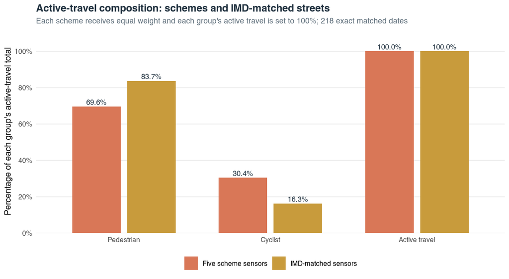

| Outcome | Scheme share | IMD-paired share | Scheme avg/day | IMD-paired avg/day |
| --- | --- | --- | --- | --- |
| Pedestrian | 69.6% | 83.7% | 96.8 | 439.2 |
| Cyclist | 30.4% | 16.3% | 31.3 | 53.3 |
| Active travel | 100.0% | 100.0% | 128.1 | 492.5 |

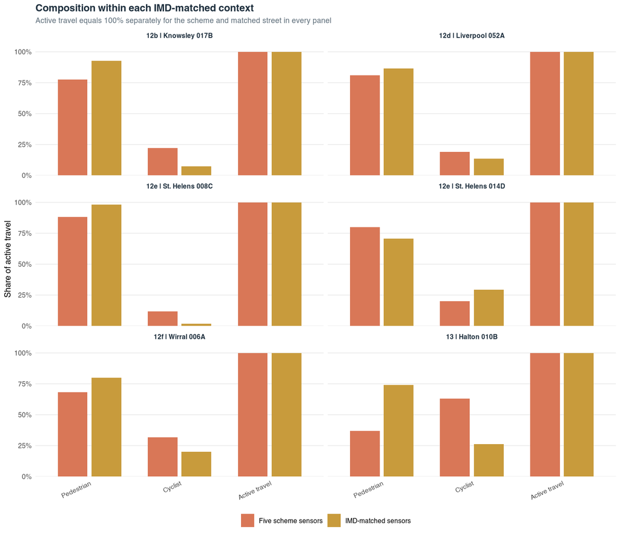

| Scheme context | Scheme pedestrian | Scheme cyclist | Paired pedestrian | Paired cyclist |
| --- | --- | --- | --- | --- |
| 12b \| Knowsley 017B | 77.7% | 22.3% | 92.6% | 7.4% |
| 12d \| Liverpool 052A | 80.9% | 19.1% | 86.4% | 13.6% |
| 12e \| St. Helens 008C | 88.3% | 11.7% | 98.3% | 1.7% |
| 12e \| St. Helens 014D | 80.1% | 19.9% | 70.6% | 29.4% |
| 12f \| Wirral 006A | 68.4% | 31.6% | 79.9% | 20.1% |
| 13 \| Halton 010B | 36.8% | 63.2% | 73.9% | 26.1% |

### Before/after change relative to the paired IMD baseline

**Revised main result:** after first averaging countlines within each street context and then giving schemes 12d and 12f equal weight, the paired IMD streets changed by -4.8% in active travel from 2022 to 2024, while the scheme contexts changed by -14.3%. The scheme trajectory was -9.9% relative to the paired baseline. A seven-day moving-block bootstrap over the selected matched dates gives a conditional interval of -16.4% to -2.4%. This interval measures date-to-date uncertainty within these chosen pairs; it does not account for uncertainty in control selection or establish causation.

**Model sensitivity:** the earlier countline-weighted fixed-effects specification estimated a larger relative difference of -30.0% with a 95% interval of -54.5% to +7.6%. Because the matched-context estimate is -9.9%, the exact magnitude and conventional significance are sensitive to weighting and model choice. The stable conclusion is directional: the analysable scheme contexts did not outperform their selected IMD matches over these windows.

**Availability:** schemes 12d and 12f use matched 2022 and 2024 month-days. Scheme 13 uses matched 2023 and 2024 month-days because its reliable record begins on 27 September 2023, before its confirmed 1 March 2024 installation. Schemes 12b and 12e have no quality-passing pre-installation scheme observations, so their matched streets can support descriptive composition and post-installation trajectory comparisons only.

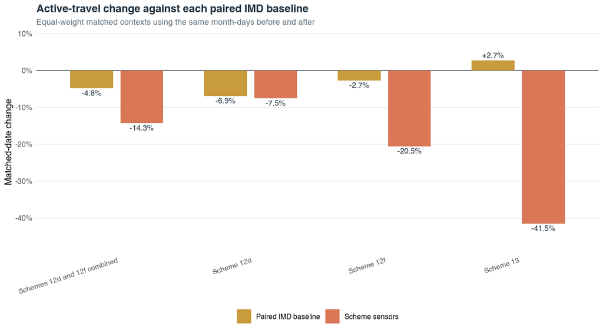

| Comparison | Years | Matched month-days | Scheme/control countlines | IMD baseline change | Scheme change | Scheme relative to baseline | Conditional block-bootstrap interval | Interpretation |
| --- | --- | --- | --- | --- | --- | --- | --- | --- |
| Schemes 12d and 12f combined | 2022 to 2024 | 12d: 39; 12f: 35 | 7 / 6 | -4.8% | -14.3% | -9.9% | -16.4% to -2.4% | Lower within selected matched dates |
| Scheme 12d | 2022 to 2024 | 39 | 4 / 3 | -6.9% | -7.5% | -0.7% | -10.6% to +12.9% | Direction uncertain within selected matched dates |
| Scheme 12f | 2022 to 2024 | 35 | 3 / 3 | -2.7% | -20.5% | -18.3% | -26.2% to -9.5% | Lower within selected matched dates |
| Scheme 13 | 2023 to 2024 | 88 | 4 / 5 | +2.7% | -41.5% | -43.0% | -58.0% to -27.7% | Lower within selected matched dates |

**Countline-weighted fixed-effects sensitivity results**

These estimates retain countlines as the modelling units and cluster standard errors by countline. They are shown to demonstrate model sensitivity, not as the preferred headline.

| Comparison | Outcome | IMD baseline change | Scheme change | Relative difference | Clustered p |
| --- | --- | --- | --- | --- | --- |
| Scheme 12d | Pedestrian | -15.8% | -23.3% | -8.9% | 0.599 |
| Scheme 12d | Cyclist | +32.5% | -12.0% | -33.6% | 0.00964 |
| Scheme 12d | Active travel | -3.0% | -13.4% | -10.7% | 0.423 |
| Scheme 12f | Pedestrian | -0.7% | -41.7% | -41.3% | 0.276 |
| Scheme 12f | Cyclist | -21.3% | -34.9% | -17.3% | 0.322 |
| Scheme 12f | Active travel | -1.2% | -51.7% | -51.1% | 0.109 |
| Scheme 13 | Pedestrian | -3.7% | -37.5% | -35.1% | 0.176 |
| Scheme 13 | Cyclist | +3.7% | -25.3% | -28.0% | 0.253 |
| Scheme 13 | Active travel | -1.6% | -36.4% | -35.4% | 0.188 |

**Interpretation limit:** IMD matching improves socioeconomic comparability, but it does not establish a valid counterfactual by itself. There are only two independent 2022–2024 matched scheme contexts, and one 2023–2024 context for scheme 13. Parallel pre-trends cannot be tested, the controls may have their own interventions, and land use, network form, traffic conditions, sensor configuration, and regression-to-the-mean remain uncontrolled. Weather is assessed separately as a model sensitivity, but that does not solve these remaining design limitations. Conditional bootstrap intervals should not be read as population-level causal confidence intervals.

Section 7

## Pre-intervention percentage-trajectory matched controls

Pedestrian and cyclist controls are selected separately using only observations before each confirmed installation date. Road/path type is not used.

**Percentage and log scale:** each treated and candidate pre-installation series is converted to an index with its own pre-period mean equal to 100. Trend models use `log(percentage index / 100)`, so matching evaluates proportional movement rather than raw count size. Absolute count levels are retained only as a broad comparability gate, requiring the candidate mean to be between one-half and twice the treated mean.

**Selection requirements:** candidates must remain within 10 IMD-score points and one IMD decile, share at least 80% of treated pre-period dates, retain at least 60% coverage in every pre-period month, have at least 75% average countline availability, show similar weekly log trends and monthly/weekday percentage profiles, and have a non-negative weekly percentage-log correlation. No candidate street is reused within the same outcome.

| Scheme | Outcome | Selected control | IMD-score difference | Shared pre-days | Count-level ratio | Weekly trend difference | Monthly percentage-shape difference | Weekly correlation |
| --- | --- | --- | --- | --- | --- | --- | --- | --- |
| 12d | Cyclist | Liverpool 042C \| fir ln | 7.480 | 85 (81.0%) | 1.03 | 0.056 | 0.222 | 0.830 |
| 12d | Pedestrian | Liverpool 060C \| london rd | 2.660 | 104 (99.0%) | 1.14 | 0.120 | 0.069 | 0.360 |
| 12f | Cyclist | Sefton 011D \| liverpool rd | 3.372 | 191 (100.0%) | 1.25 | 0.215 | 0.074 | 0.947 |
| 12f | Pedestrian | Sefton 009A \| dover rd | 3.275 | 187 (97.9%) | 1.13 | 0.176 | 0.055 | 0.933 |
| 13 | Cyclist | Liverpool 024D \| west derby rd | 0.388 | 156 (100.0%) | 0.94 | 0.220 | 0.193 | 0.903 |
| 13 | Pedestrian | Halton 015B \| busway | 5.994 | 154 (98.7%) | 0.56 | 0.747 | 0.704 | 0.086 |

**Availability:** trajectory matching is possible only for schemes 12d, 12f, and 13. Schemes 12b and 12e have no quality-passing treated observations before their confirmed installation dates, so their pre-intervention percentage trends cannot be estimated.

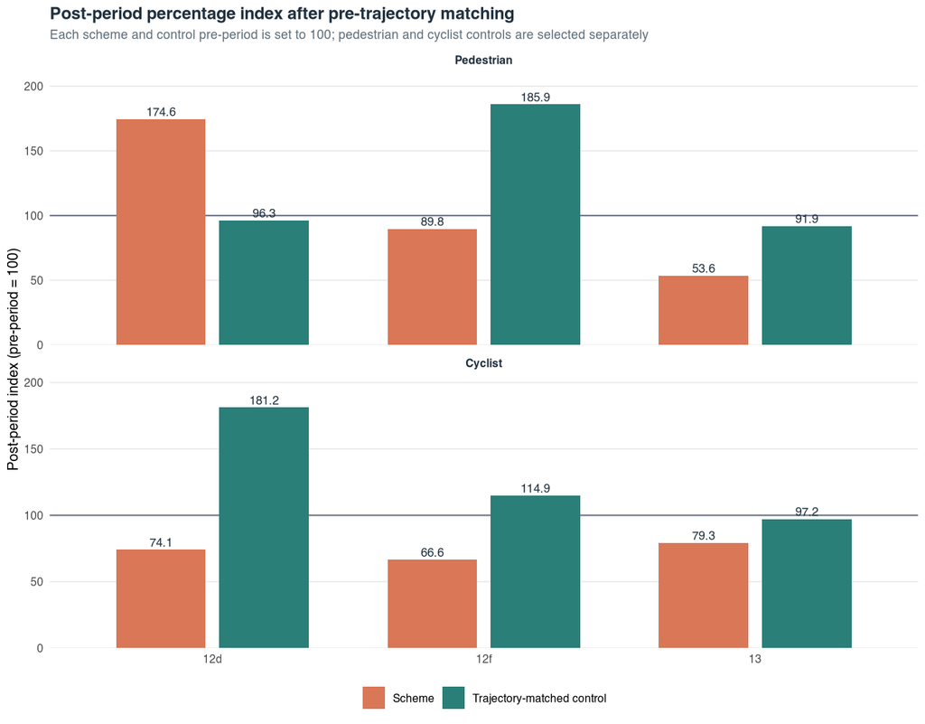

| Scheme | Outcome | Years | Matched month-days | Scheme post-index | Control post-index | Scheme relative to control |
| --- | --- | --- | --- | --- | --- | --- |
| 12d | Cyclist | 2022 to 2024 | 38 | 74.1 | 181.2 | -59.1% |
| 12d | Pedestrian | 2022 to 2024 | 46 | 174.6 | 96.3 | +81.3% |
| 12d + 12f equal-weight | Cyclist | 2022 to 2024 | Equal-weight 12d/12f | 70.2 | 144.3 | -51.3% |
| 12d + 12f equal-weight | Pedestrian | 2022 to 2024 | Equal-weight 12d/12f | 125.2 | 133.8 | -6.4% |
| 12f | Cyclist | 2022 to 2024 | 47 | 66.6 | 114.9 | -42.1% |
| 12f | Pedestrian | 2022 to 2024 | 45 | 89.8 | 185.9 | -51.7% |
| 13 | Cyclist | 2023 to 2024 | 94 | 79.3 | 97.2 | -18.5% |
| 13 | Pedestrian | 2023 to 2024 | 92 | 53.6 | 91.9 | -41.7% |

**Equal-weight 12d/12f result:** after selecting different controls for each mode and setting every pre-period to 100, the combined pedestrian index is 125.2 for the schemes and 133.8 for their controls, a relative difference of -6.4%. For cyclists, the scheme index is 70.2 and the control index is 144.3, a relative difference of -51.3%.

**Interpretation limit:** this improves pre-intervention comparability but remains a sensitivity analysis. The pre-period is short, especially for scheme 12d; scheme 13 has only one qualifying pedestrian control; and the selected streets still require external verification that no other intervention affected them.

Section 8

## Weather-control feasibility and sensitivity

Daily ERA5 reanalysis is linked to each matched scheme/control context and to a Liverpool City Region area-average series.

**Feasibility:** weather control is feasible and reproducible for this project. The model uses daily mean temperature, precipitation, maximum 10 m wind speed, and shortwave solar radiation from 1 January 2020 to 31 May 2025. The source is ERA5 through the Open-Meteo Historical Weather API, using Europe/London dates. Data are complete for 12 matched context locations.

**How to interpret it:** the existing exact-date matching already removes most broad weather differences because scheme and comparison sensors are observed on the same days. The weather-adjusted models therefore test residual differences between years and locations; they are sensitivity analyses, not a cure for non-random scheme placement or weak control matching.

**Active-travel result:** against the wider LCR benchmark, the relative estimate changes from -33.0% to -33.4% after weather adjustment, a shift of -0.4 percentage points. In the combined 12d/12f IMD-context regression sensitivity, it changes from -9.9% to -10.3%, a shift of -0.3 percentage points. The preferred equal-context matched-date estimate remains -9.9%; weather adjustment is reported alongside it rather than replacing it.

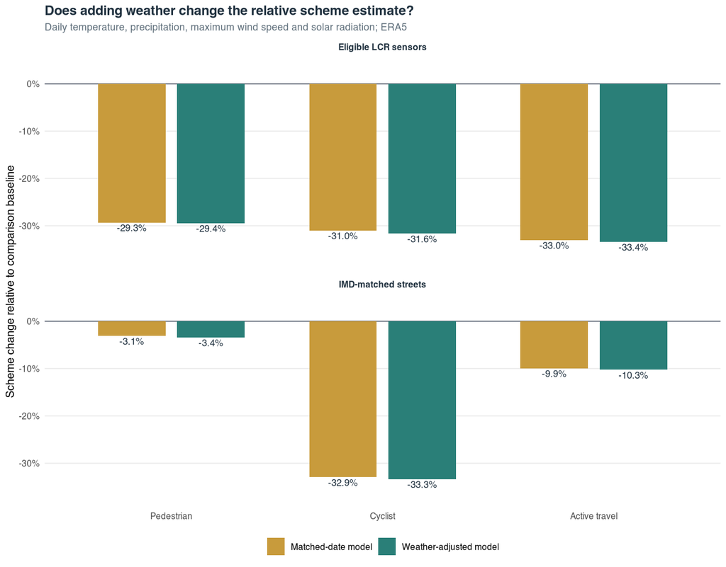

| Benchmark | Outcome | Matched-date estimate | Weather-adjusted estimate | Adjustment shift | Sensitivity |
| --- | --- | --- | --- | --- | --- |
| Eligible LCR sensors | Active travel | -33.0% | -33.4% | -0.4 percentage points | Minimal change |
| Eligible LCR sensors | Cyclist | -31.0% | -31.6% | -0.6 percentage points | Minimal change |
| Eligible LCR sensors | Pedestrian | -29.3% | -29.4% | -0.1 percentage points | Minimal change |
| IMD-matched streets | Pedestrian | -3.1% | -3.4% | -0.3 percentage points | Minimal change |
| IMD-matched streets | Cyclist | -32.9% | -33.3% | -0.4 percentage points | Minimal change |
| IMD-matched streets | Active travel | -9.9% | -10.3% | -0.3 percentage points | Minimal change |

**Resolution limit:** ERA5 is gridded reanalysis at approximately 0.25 degrees, about 25 km, so it represents city-region daily conditions rather than rain or wind measured directly at each street. It is suitable for controlling broad daily weather but cannot capture a short local shower, shade, surface condition, or microclimate at an individual sensor.

Section 9

## Road and path/cycle-facility outcomes within the five schemes

Separating route type prevents pedestrian-heavy paths and cyclist-heavy road countlines from being blended without explanation.

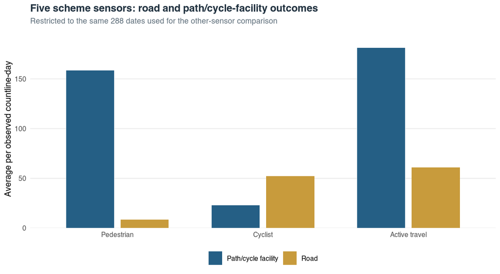

| Route type | Outcome | Sensors | Observed sensor-days | Average/day |
| --- | --- | --- | --- | --- |
| Road | Pedestrian | 7 | 1,818 | 8.6 |
| Path/cycle facility | Pedestrian | 13 | 3,489 | 158.5 |
| Road | Cyclist | 7 | 1,818 | 52.3 |
| Path/cycle facility | Cyclist | 13 | 3,489 | 22.9 |
| Road | Active travel | 7 | 1,818 | 60.9 |
| Path/cycle facility | Active travel | 13 | 3,489 | 181.4 |

Section 10

## Methods and definitions

**Official source**

The citywide comparison uses 90 Vivacity dashboard hourly exports covering 711 Liverpool City Region countlines from 1 January 2020 to 31 May 2025. The fixed-year scheme panels additionally use the validated scheme-only daily archive through 26 May 2026; the partial 2026 period is used only for the requested Scheme 13 comparison.

**Scheme countlines**

21 countlines are linked to schemes 12b, 12d, 12e, 12f, and 13; 20 have at least one quality-passing observation on the exact matched dates. Exact installation dates are 12b: 2023-03-01; 12d: 2023-03-01; 12e: 2023-03-01; 12f: 2023-06-01; 13: 2024-03-01.

**Quality rule**

At least 23 distinct hourly periods must be present, with non-missing availability and both pedestrian and cyclist fields observed in at least 23 hourly periods. Daily minimum reported availability must be at least 80%, and no data error may be recorded. The 23-hour threshold retains daylight-saving transition days while excluding incomplete export-boundary fragments. Scheme-sensor dates must also be on or after the confirmed first reliable date.

**Outcome**

Full-day pedestrian, cyclist, and active-travel counts. Active travel equals pedestrian plus cyclist. Despite the legacy filename, these figures are not AM/PM peak-hour counts.

**Denominator**

Count totals divided by observed countline-days, so unavailable sensor-days are excluded rather than entered as zero.

**Percentage normalization**

For the scheme-versus-other bar chart, each group’s pooled active-travel average is set to 100%. Pedestrian and cyclist values are divided by that group-specific active-travel average. This removes the level difference for visual comparison but does not imply equal absolute volumes.

**Baseline regression**

A log-linear difference-in-differences model compares 2022 with 2024 using paired calendar days from 15 November to 31 December. The model includes a general 2024 LCR-comparison change, an additional scheme-by-2024 term, countline fixed effects, month-day controls, and weekday controls. Standard errors are clustered by countline. Sensors require at least 20 paired month-days. The final cohort contains 7 treated countlines from schemes 12d and 12f and 126 eligible other LCR countlines. Because only seven treated countlines are available, an equal-weight sensor-level Welch test is also reported as a robustness check. Parallel pre-trends cannot be tested from the short baseline.

**IMD matching**

Matching uses the continuous 2019 Index of Multiple Deprivation score assigned to each sensor’s LSOA 2021 area. The closest available route-compatible non-intervention street is selected for each of the six treated LSOA contexts. Continuous score distance is ranked before decile agreement because close scores can fall on opposite sides of a decile boundary. Scheme 12e is represented by two separate LSOA-context pairs rather than one averaged deprivation value.

**IMD composition comparison**

Every scheme context and paired street must have at least one quality-passing observation on a retained calendar date. Across the resulting 218 dates, totals are divided by observed countline-days and active travel is set to 100% within each scheme and paired-control group. Scheme 12e’s two contexts are combined at scheme level. The five scheme-level percentages are then averaged with equal weight, preventing schemes with more sensors or more observed days from dominating the headline composition.

**Preferred IMD change estimator**

For each analysable pair and matched month-day, countlines are first averaged into one scheme-context value and one paired-control-context value. Pre/post log changes are calculated within each context and differenced between scheme and control. Schemes 12d and 12f use 2022–2024 comparisons and receive equal weight in the combined estimate; scheme 13 uses 2023–2024. Seven-day circular moving-block resampling provides an interval for date-to-date uncertainty conditional on the selected pairs. It does not capture control-selection uncertainty and is not a causal population confidence interval.

**Countline-model sensitivity**

A log-linear fixed-effects model is retained as a sensitivity analysis. It includes countline fixed effects, common month-day controls, weekday controls, and countline-clustered standard errors. Its larger estimated effect demonstrates that the magnitude and conventional inference are sensitive to weighting and model structure.

**Pre-intervention trajectory matching**

Pedestrian and cyclist controls are selected separately. Within each mode, treated and candidate pre-installation daily series are divided by their own pre-period means and multiplied by 100. Weekly trend models use log(percentage index / 100). Matching also compares monthly and weekday percentage profiles, shared-date and monthly coverage, countline availability, broad count-level comparability, and IMD proximity. Road/path type is recorded but is not used for selection. Candidates require at least 80% shared dates, 60% coverage in every pre-period month, 75% countline availability, a count-level ratio from 0.5 to 2.0, an IMD-score difference no greater than 10, an IMD-decile difference no greater than one, and a non-negative weekly percentage-log correlation.

**Weather source**

Daily weather is drawn from ERA5 reanalysis through the Open-Meteo Historical Weather API for 1 January 2020 to 31 May 2025. Twelve scheme/control context centroids are used. Variables are daily mean 2 m temperature in degrees Celsius, precipitation sum in millimetres, maximum 10 m wind speed in kilometres per hour, and shortwave solar radiation in megajoules per square metre. Dates use the Europe/London timezone. ERA5 has approximately 0.25-degree, about 25 km, spatial resolution and should be interpreted as city-region weather.

**Weather-adjusted sensitivity**

The LCR and IMD-context log-linear models are re-estimated after adding standardized temperature, log-transformed precipitation, maximum wind speed, and shortwave solar radiation. The LCR model uses the daily mean across the twelve context grids; the IMD model uses each scheme or control context’s grid. The weather-adjusted coefficient is compared directly with the corresponding model without weather. It is not substituted for the preferred matched-context estimate because exact-date matching already controls common daily weather and because only two independent 2022–2024 scheme contexts are available.

**Other-sensor eligibility**

An other LCR countline is included only if it has at least one quality-passing full day in both 2022 and 2024. This retains 149 of 637 other countlines and excludes 488. No other countline has usable 2021 data, so no LCR-wide comparison beginning in 2021 is reported.

**Exact day matching**

For the scheme-versus-other contextual comparison, a calendar date is retained only when every one of the five scheme groups has at least one quality-passing observation. The eligible other LCR sensors are then filtered to precisely those 288 dates, spanning 2024-08-01 to 2025-05-31.

Analysis integrity audit CSVTrajectory-selected controls CSVAll trajectory candidate scores CSVTrajectory comparison results CSVUnavailable schemes CSVLCR baseline results CSVWeather-adjusted LCR model CSVWeather sensitivity summary CSVWeather site lookup CSVDaily ERA5 weather CSVIMD weather sensitivity CSVLCR regression cohort CSVIMD matched pairs CSVEqual-scheme IMD composition CSVPreferred IMD context-change results CSVCountline-model sensitivity CSVIMD match diagnostics CSVIMD baseline cohort CSVIMD exact dates CSVOther-sensor eligibility CSVOther-sensor before/after CSVExact five-scheme dates CSVMonthly comparison CSVMatched-day comparison CSVLocal-authority summary CSVRoad/path comparison CSV[Open-Meteo historical weather documentation](https://open-meteo.com/en/docs/historical-weather-api)[Copernicus ERA5 dataset](https://cds.climate.copernicus.eu/datasets/reanalysis-era5-single-levels)

Generated from the validated official dashboard exports. Updated 15 June 2026.